# 2일차

```python
import pandas as pd
import numpy as np
import seaborn as sns
import matplotlib.pyplot as plt
%matplotlib inline
```

```python
df = pd.read_csv('test1_modify2.csv')
df
```

|  | datetime | type | gender | age |
| --- | --- | --- | --- | --- |
| 0 | 2019-12-01 00:00:00 | regular | U | 10s |
| 1 | 2019-12-01 00:00:00 | regular | U | 10s |
| 2 | 2019-12-01 00:00:00 | regular | U | 10s |
| 3 | 2019-12-01 00:00:00 | regular | U | 10s |
| 4 | 2019-12-01 00:00:00 | regular | U | 10s |
| ... | ... | ... | ... | ... |
| 45108024 | 2018-11-30 23:00:00 | casual | M | 30s |
| 45108025 | 2018-11-30 23:00:00 | casual | M | 30s |
| 45108026 | 2018-11-30 23:00:00 | casual | M | 40s |
| 45108027 | 2018-11-30 23:00:00 | casual | M | 60s |
| 45108028 | 2018-11-30 23:00:00 | casual | M | 30s |

45108029 rows × 4 columns

#### Data Handling - 시간대별 고객의 유형별 이용건수

```python
# 모든 Row를 Count라는 컬럼을 만들어서 1로 저장하고,
# datetime 기준으로 그룹지어서 특정 시간대에 몇 명이 이용했는지 확인

df['count'] = 1
df.groupby('datetime').agg({'count': np.sum})

# 해당 시간대에서 이용한 인원수를 나타냄
```

| datetime | count |
| --- | --- |
| 2017-01-01 00:00:00 | 77 |
| 2017-01-01 01:00:00 | 76 |
| 2017-01-01 02:00:00 | 57 |
| 2017-01-01 03:00:00 | 34 |
| 2017-01-01 04:00:00 | 23 |
| ... | ... |
| 2021-01-31 19:00:00 | 1890 |
| 2021-01-31 20:00:00 | 1894 |
| 2021-01-31 21:00:00 | 1836 |
| 2021-01-31 22:00:00 | 1043 |
| 2021-01-31 23:00:00 | 694 |

35351 rows × 1 columns

```python
df.loc[df['type'] == 'regular']
```

|  | datetime | type | gender | age | count |
| --- | --- | --- | --- | --- | --- |
| 0 | 2019-12-01 00:00:00 | regular | U | 10s | 1 |
| 1 | 2019-12-01 00:00:00 | regular | U | 10s | 1 |
| 2 | 2019-12-01 00:00:00 | regular | U | 10s | 1 |
| 3 | 2019-12-01 00:00:00 | regular | U | 10s | 1 |
| 4 | 2019-12-01 00:00:00 | regular | U | 10s | 1 |
| ... | ... | ... | ... | ... | ... |
| 45107957 | 2018-11-30 23:00:00 | regular | M | 60s | 1 |
| 45107958 | 2018-11-30 23:00:00 | regular | M | 60s | 1 |
| 45107959 | 2018-11-30 23:00:00 | regular | M | 60s | 1 |
| 45107960 | 2018-11-30 23:00:00 | regular | M | 60s | 1 |
| 45107961 | 2018-11-30 23:00:00 | regular | M | 70s | 1 |

35629216 rows × 5 columns

```python
df['count'] = 1

reg = df.loc[df['type'] == 'regular']
reg.groupby('datetime').agg({'count': np.sum})

# 정기권인 분들을 모아 시간대별 이용량을 구함
```

| datetime | count |
| --- | --- |
| 2017-01-01 00:00:00 | 63 |
| 2017-01-01 01:00:00 | 55 |
| 2017-01-01 02:00:00 | 38 |
| 2017-01-01 03:00:00 | 22 |
| 2017-01-01 04:00:00 | 16 |
| ... | ... |
| 2021-01-31 19:00:00 | 1346 |
| 2021-01-31 20:00:00 | 1298 |
| 2021-01-31 21:00:00 | 1229 |
| 2021-01-31 22:00:00 | 750 |
| 2021-01-31 23:00:00 | 496 |

35343 rows × 1 columns

```python
# regular
reg = df.loc[df['type'] == 'regular']
reg = reg.groupby('datetime').agg({'count': np.sum}).reset_index()
reg.columns = ['datetime', 'regular']

# casual
cas = df.loc[df['type'] == 'casual']
cas = cas.groupby('datetime').agg({'count': np.sum}).reset_index()
cas.columns = ['datetime', 'casual']

# group
gro = df.loc[df['type'] == 'group']
gro = gro.groupby('datetime').agg({'count': np.sum}).reset_index()
gro.columns = ['datetime', 'group']
```

```python
reg
# cas
# gro
```

|  | datetime | regular |
| --- | --- | --- |
| 0 | 2017-01-01 00:00:00 | 63 |
| 1 | 2017-01-01 01:00:00 | 55 |
| 2 | 2017-01-01 02:00:00 | 38 |
| 3 | 2017-01-01 03:00:00 | 22 |
| 4 | 2017-01-01 04:00:00 | 16 |
| ... | ... | ... |
| 35338 | 2021-01-31 19:00:00 | 1346 |
| 35339 | 2021-01-31 20:00:00 | 1298 |
| 35340 | 2021-01-31 21:00:00 | 1229 |
| 35341 | 2021-01-31 22:00:00 | 750 |
| 35342 | 2021-01-31 23:00:00 | 496 |

35343 rows × 2 columns

```python
print(reg.shape)
print(cas.shape)
print(gro.shape)

# 그룹으로 관리하니 총 Row의 개수가 확연히 줄어들어 관리가 용이
```

```
(35343, 2)
(35048, 2)
(23985, 2)
```

```python
pd.merge(reg, cas, how='outer')
```

|  | datetime | regular | casual |
| --- | --- | --- | --- |
| 0 | 2017-01-01 00:00:00 | 63.0 | 13.0 |
| 1 | 2017-01-01 01:00:00 | 55.0 | 21.0 |
| 2 | 2017-01-01 02:00:00 | 38.0 | 19.0 |
| 3 | 2017-01-01 03:00:00 | 22.0 | 12.0 |
| 4 | 2017-01-01 04:00:00 | 16.0 | 7.0 |
| ... | ... | ... | ... |
| 35346 | 2017-03-17 05:00:00 | NaN | 1.0 |
| 35347 | 2017-03-17 09:00:00 | NaN | 2.0 |
| 35348 | 2017-07-05 18:00:00 | NaN | 3.0 |
| 35349 | 2017-07-05 20:00:00 | NaN | 1.0 |
| 35350 | 2017-07-06 11:00:00 | NaN | 2.0 |

35351 rows × 3 columns

```python
rc = pd.merge(reg, cas, how='outer')
rcg = pd.merge(rc, gro, how='outer')
rcg

# regular, casual, group을 만드는 것은 결국에는 Label을 만드는 것으로 분석 방향성이 설정된 것
# -> 시간에 따른 이용 변화와 고객을 분류할 수 있는 기준
```

|  | datetime | regular | casual | group |
| --- | --- | --- | --- | --- |
| 0 | 2017-01-01 00:00:00 | 63.0 | 13.0 | 1.0 |
| 1 | 2017-01-01 01:00:00 | 55.0 | 21.0 | NaN |
| 2 | 2017-01-01 02:00:00 | 38.0 | 19.0 | NaN |
| 3 | 2017-01-01 03:00:00 | 22.0 | 12.0 | NaN |
| 4 | 2017-01-01 04:00:00 | 16.0 | 7.0 | NaN |
| ... | ... | ... | ... | ... |
| 35346 | 2017-03-17 05:00:00 | NaN | 1.0 | NaN |
| 35347 | 2017-03-17 09:00:00 | NaN | 2.0 | NaN |
| 35348 | 2017-07-05 18:00:00 | NaN | 3.0 | NaN |
| 35349 | 2017-07-05 20:00:00 | NaN | 1.0 | NaN |
| 35350 | 2017-07-06 11:00:00 | NaN | 2.0 | NaN |

35351 rows × 4 columns

```python
rcg = rcg.fillna(0)
rcg

# 시간대별 고객의 유형별 이용량을 확인할 수 있음
# 현재는 type 컬럼을 가지고 했지만, age나 gender의 경우의 수를 대상으로도 해보세요.
```

|  | datetime | regular | casual | group |
| --- | --- | --- | --- | --- |
| 0 | 2017-01-01 00:00:00 | 63.0 | 13.0 | 1.0 |
| 1 | 2017-01-01 01:00:00 | 55.0 | 21.0 | 0.0 |
| 2 | 2017-01-01 02:00:00 | 38.0 | 19.0 | 0.0 |
| 3 | 2017-01-01 03:00:00 | 22.0 | 12.0 | 0.0 |
| 4 | 2017-01-01 04:00:00 | 16.0 | 7.0 | 0.0 |
| ... | ... | ... | ... | ... |
| 35346 | 2017-03-17 05:00:00 | 0.0 | 1.0 | 0.0 |
| 35347 | 2017-03-17 09:00:00 | 0.0 | 2.0 | 0.0 |
| 35348 | 2017-07-05 18:00:00 | 0.0 | 3.0 | 0.0 |
| 35349 | 2017-07-05 20:00:00 | 0.0 | 1.0 | 0.0 |
| 35350 | 2017-07-06 11:00:00 | 0.0 | 2.0 | 0.0 |

35351 rows × 4 columns

```python
rcg.to_csv('test1_modify3.csv', index=False)
```

#### Data Handling - 날씨 정보 가져오기

- 우리가 하고자 하는 것은 자전거 이용량에 대한 것이므로 의미가 있는 데이터를 가져와야 함
- 예를 들어 날씨 정보는 날씨에 따라 이용량에 영향이 있을 것으로 판단
- 반대로 부동산의 가격에 따른 자전거 대여 이용량은 영향이 없을 것으로 추가 X
- 이용량 변화에 영향이 있을만한 정보를 가져올 수 있어야 함

```python
url = 'https://freemeteo.co.uk/weather/seoul/history/daily-history/?gid=1835848&station=10565&date='
date = '2020-01-01'
end = '&language=english&country=south-korea'
one_page = pd.read_html(url + date + end)
one_page
```

```
[             Name           Weather forecast Altitiude  Population
 0           Seoul  Today | Tomorrow | 7 days       46m  10349312.0
 1             NaN  Today | Tomorrow | 7 days       12m         NaN
 2             NaN  Today | Tomorrow | 7 days       43m         NaN
 3             NaN  Today | Tomorrow | 7 days       13m         NaN
 4      Ahyon-dong  Today | Tomorrow | 7 days       27m         NaN
 5     Ahyoni-dong  Today | Tomorrow | 7 days       47m         NaN
 6    Ahyonil-tong  Today | Tomorrow | 7 days       65m         NaN
 7   Ahyonsam-dong  Today | Tomorrow | 7 days       47m         NaN
 8      Amsai-dong  Today | Tomorrow | 7 days        1m         NaN
 9     Amsail-tong  Today | Tomorrow | 7 days       18m         NaN
 10          Amsan  Today | Tomorrow | 7 days       27m         NaN
 11    Amsasa-dong  Today | Tomorrow | 7 days       26m         NaN
 12   Amsasam-dong  Today | Tomorrow | 7 days       23m         NaN
 13         An'gol  Today | Tomorrow | 7 days       58m         NaN
```

[output cut: 306 more lines]

```python
weather_df = one_page[6]
weather_df['date'] = date
weather_df.to_csv('weather_sample.csv', index=False)
```

```python
def save_weather(date):
    url = 'https://freemeteo.co.uk/weather/seoul/history/daily-history/?gid=1835848&station=10565&date='
    end = '&language=english&country=south-korea'
    one_page = pd.read_html(url + date + end)
    weather_df = one_page[6]
    weather_df['date'] = date
    weather_df.to_csv(date + '.csv', index=False)
```

```python
import time

for date in pd.date_range('2017-01-01', '2021-01-31'):
    save_weather(str(date)[:10])
    time.sleep(2)
```

[output not shown]

```python
from glob import glob

weather_path = 'C:/Users/user/ML/weather'
glob(weather_path + '/*.csv')
```

```
['C:/Users/user/ML/weather\\2017-01-01.csv',
 'C:/Users/user/ML/weather\\2017-01-02.csv',
 'C:/Users/user/ML/weather\\2017-01-03.csv',
 'C:/Users/user/ML/weather\\2017-01-04.csv',
 'C:/Users/user/ML/weather\\2017-01-05.csv',
 'C:/Users/user/ML/weather\\2017-01-06.csv',
 'C:/Users/user/ML/weather\\2017-01-07.csv',
 'C:/Users/user/ML/weather\\2017-01-08.csv',
 'C:/Users/user/ML/weather\\2017-01-09.csv',
 'C:/Users/user/ML/weather\\2017-01-10.csv',
 'C:/Users/user/ML/weather\\2017-01-11.csv',
 'C:/Users/user/ML/weather\\2017-01-12.csv',
 'C:/Users/user/ML/weather\\2017-01-13.csv',
 'C:/Users/user/ML/weather\\2017-01-14.csv',
 'C:/Users/user/ML/weather\\2017-01-15.csv',
 'C:/Users/user/ML/weather\\2017-01-16.csv',
 'C:/Users/user/ML/weather\\2017-01-17.csv',
 'C:/Users/user/ML/weather\\2017-01-18.csv',
 'C:/Users/user/ML/weather\\2017-01-19.csv',
 'C:/Users/user/ML/weather\\2017-01-20.csv',
 'C:/Users/user/ML/weather\\2017-01-21.csv',
 'C:/Users/user/ML/weather\\2017-01-22.csv',
 'C:/Users/user/ML/weather\\2017-01-23.csv',
 'C:/Users/user/ML/weather\\2017-01-24.csv',
 'C:/Users/user/ML/weather\\2017-01-25.csv',
 'C:/Users/user/ML/weather\\2017-01-26.csv',
 'C:/Users/user/ML/weather\\2017-01-27.csv',
 'C:/Users/user/ML/weather\\2017-01-28.csv',
 'C:/Users/user/ML/weather\\2017-01-29.csv',
 'C:/Users/user/ML/weather\\2017-01-30.csv',
 'C:/Users/user/ML/weather\\2017-01-31.csv',
 'C:/Users/user/ML/weather\\2017-02-01.csv',
 'C:/Users/user/ML/weather\\2017-02-02.csv',
 'C:/Users/user/ML/weather\\2017-02-03.csv',
 'C:/Users/user/ML/weather\\2017-02-04.csv',
 'C:/Users/user/ML/weather\\2017-02-05.csv',
 'C:/Users/user/ML/weather\\2017-02-06.csv',
 'C:/Users/user/ML/weather\\2017-02-07.csv',
 'C:/Users/user/ML/weather\\2017-02-08.csv',
 'C:/Users/user/ML/weather\\2017-02-09.csv',
```

[output cut: 946 more lines]

```
 'C:/Users/user/ML/weather\\2019-09-14.csv',
 'C:/Users/user/ML/weather\\2019-09-15.csv',
 'C:/Users/user/ML/weather\\2019-09-16.csv',
 'C:/Users/user/ML/weather\\2019-09-17.csv',
 'C:/Users/user/ML/weather\\2019-09-18.csv',
 'C:/Users/user/ML/weather\\2019-09-19.csv',
 'C:/Users/user/ML/weather\\2019-09-20.csv',
 'C:/Users/user/ML/weather\\2019-09-21.csv',
 'C:/Users/user/ML/weather\\2019-09-22.csv',
 'C:/Users/user/ML/weather\\2019-09-23.csv',
 'C:/Users/user/ML/weather\\2019-09-24.csv',
 'C:/Users/user/ML/weather\\2019-09-25.csv',
 'C:/Users/user/ML/weather\\2019-09-26.csv',
 'C:/Users/user/ML/weather\\2019-09-27.csv',
 ...]
```

```python
pd.read_csv(glob(weather_path + '/*.csv')[0]).head()

# 어떤 날 몇 시에 날시 정보를 확인할 수 있음
# 같은 사이트에서 날짜만 다르게 가져왔으므로 데이터의 형태는 동일하다고 가정
```

|  | Time | Temperature | Relative Temperature | Wind | Wind Gust | Rel. humidity | Dew Point | Pressure | Icon | DescriptionDetails | date |
| --- | --- | --- | --- | --- | --- | --- | --- | --- | --- | --- | --- |
| 0 | 00:00 | -1°C | -4°C | 150°9 Km/h | NaN | 75% | -5°C | 1029.0mb | NaN | document.write(Icons.GetShortDescription(2, 'C... | 2017-01-01 |
| 1 | 01:00 | -2°C | -5°C | 160°9 Km/h | NaN | 80% | -5°C | 1029.0mb | NaN | document.write(Icons.GetShortDescription(2, 'C... | 2017-01-01 |
| 2 | 02:00 | -3°C | -6°C | 160°7 Km/h | NaN | 74% | -7°C | 1029.0mb | NaN | document.write(Icons.GetShortDescription(2, 'C... | 2017-01-01 |
| 3 | 03:00 | -3°C | -3°C | 170°4 Km/h | NaN | 80% | -6°C | 1029.0mb | NaN | document.write(Icons.GetShortDescription(2, 'C... | 2017-01-01 |
| 4 | 04:00 | -3°C | -6°C | 160°7 Km/h | NaN | 80% | -6°C | 1029.0mb | NaN | document.write(Icons.GetShortDescription(2, 'C... | 2017-01-01 |

```python
weather_list = []

for path in glob(weather_path + '/*.csv'):
    weather_list.append(pd.read_csv(path))

all_weather = pd.concat(weather_list)
all_weather
```

|  | Time | Temperature | Relative Temperature | Wind | Wind Gust | Rel. humidity | Dew Point | Pressure | Icon | DescriptionDetails | date |
| --- | --- | --- | --- | --- | --- | --- | --- | --- | --- | --- | --- |
| 0 | 00:00 | -1°C | -4°C | 150°9 Km/h | NaN | 75% | -5°C | 1029.0mb | NaN | document.write(Icons.GetShortDescription(2, 'C... | 2017-01-01 |
| 1 | 01:00 | -2°C | -5°C | 160°9 Km/h | NaN | 80% | -5°C | 1029.0mb | NaN | document.write(Icons.GetShortDescription(2, 'C... | 2017-01-01 |
| 2 | 02:00 | -3°C | -6°C | 160°7 Km/h | NaN | 74% | -7°C | 1029.0mb | NaN | document.write(Icons.GetShortDescription(2, 'C... | 2017-01-01 |
| 3 | 03:00 | -3°C | -3°C | 170°4 Km/h | NaN | 80% | -6°C | 1029.0mb | NaN | document.write(Icons.GetShortDescription(2, 'C... | 2017-01-01 |
| 4 | 04:00 | -3°C | -6°C | 160°7 Km/h | NaN | 80% | -6°C | 1029.0mb | NaN | document.write(Icons.GetShortDescription(2, 'C... | 2017-01-01 |
| ... | ... | ... | ... | ... | ... | ... | ... | ... | ... | ... | ... |
| 19 | 19:00 | 6°C | 5°C | 150°6 Km/h | NaN | 66% | 0°C | 1023.0mb | NaN | document.write(Icons.GetShortDescription(3, 'C... | 2021-01-31 |
| 20 | 20:00 | 6°C | 4°C | 150°7 Km/h | NaN | 66% | 0°C | 1022.0mb | NaN | document.write(Icons.GetShortDescription(3, 'C... | 2021-01-31 |
| 21 | 21:00 | 6°C | 4°C | 130°9 Km/h | NaN | 66% | 0°C | 1022.0mb | NaN | document.write(Icons.GetShortDescription(3, 'C... | 2021-01-31 |
| 22 | 22:00 | 6°C | 4°C | 160°9 Km/h | NaN | 66% | 0°C | 1021.0mb | NaN | document.write(Icons.GetShortDescription(3, 'C... | 2021-01-31 |
| 23 | 23:00 | 6°C | 6°C | 90°2 Km/h | NaN | 71% | 1°C | 1021.0mb | NaN | document.write(Icons.GetShortDescription(3, 'C... | 2021-01-31 |

32513 rows × 11 columns

```python
all_weather.head()
```

|  | Time | Temperature | Relative Temperature | Wind | Wind Gust | Rel. humidity | Dew Point | Pressure | Icon | DescriptionDetails | date |
| --- | --- | --- | --- | --- | --- | --- | --- | --- | --- | --- | --- |
| 0 | 00:00 | -1°C | -4°C | 150°9 Km/h | NaN | 75% | -5°C | 1029.0mb | NaN | document.write(Icons.GetShortDescription(2, 'C... | 2017-01-01 |
| 1 | 01:00 | -2°C | -5°C | 160°9 Km/h | NaN | 80% | -5°C | 1029.0mb | NaN | document.write(Icons.GetShortDescription(2, 'C... | 2017-01-01 |
| 2 | 02:00 | -3°C | -6°C | 160°7 Km/h | NaN | 74% | -7°C | 1029.0mb | NaN | document.write(Icons.GetShortDescription(2, 'C... | 2017-01-01 |
| 3 | 03:00 | -3°C | -3°C | 170°4 Km/h | NaN | 80% | -6°C | 1029.0mb | NaN | document.write(Icons.GetShortDescription(2, 'C... | 2017-01-01 |
| 4 | 04:00 | -3°C | -6°C | 160°7 Km/h | NaN | 80% | -6°C | 1029.0mb | NaN | document.write(Icons.GetShortDescription(2, 'C... | 2017-01-01 |

#### all_weather 수정사항 1

- date와 time 컬럼을 이용해서 년월일시분초 형식으로 표현

```python
set(all_weather['Time'].apply(lambda x : len(x)))
```

```
{5}
```

```python
set(all_weather['Time'].apply(lambda x : x[:2]))
```

```
{'00',
 '01',
 '02',
 '03',
 '04',
 '05',
 '06',
 '07',
 '08',
 '09',
 '10',
 '11',
 '12',
 '13',
 '14',
 '15',
 '16',
 '17',
 '18',
 '19',
 '20',
 '21',
 '22',
 '23'}
```

```python
set(all_weather['Time'].apply(lambda x : x.split(':')[1])) # x[-2:]도 같은 표현
```

```
{'00',
 '03',
 '04',
 '05',
 '06',
 '07',
 '08',
 '09',
 '10',
 '11',
 '12',
 '13',
 '14',
 '15',
 '16',
 '17',
 '18',
 '19',
 '20',
 '21',
 '22',
 '23',
 '24',
 '25',
 '26',
 '27',
 '28',
 '29',
 '30',
 '31',
 '32',
 '33',
 '34',
 '35',
 '36',
 '37',
 '38',
 '39',
 '40',
 '41',
 '42',
 '43',
 '44',
 '45',
 '46',
 '47',
 '48',
 '49',
 '50',
 '51',
 '52',
 '53',
 '54',
 '55',
 '56',
 '57',
 '58',
 '59'}
```

```python
all_weather['Time'] = all_weather['Time'].apply(lambda x : x[:2])
all_weather['datetime'] = all_weather['date'] + ' ' + all_weather['Time'] + ':00:00'
all_weather.head()
```

|  | Time | Temperature | Relative Temperature | Wind | Wind Gust | Rel. humidity | Dew Point | Pressure | Icon | DescriptionDetails | date | datetime |
| --- | --- | --- | --- | --- | --- | --- | --- | --- | --- | --- | --- | --- |
| 0 | 00 | -1°C | -4°C | 150°9 Km/h | NaN | 75% | -5°C | 1029.0mb | NaN | document.write(Icons.GetShortDescription(2, 'C... | 2017-01-01 | 2017-01-01 00:00:00 |
| 1 | 01 | -2°C | -5°C | 160°9 Km/h | NaN | 80% | -5°C | 1029.0mb | NaN | document.write(Icons.GetShortDescription(2, 'C... | 2017-01-01 | 2017-01-01 01:00:00 |
| 2 | 02 | -3°C | -6°C | 160°7 Km/h | NaN | 74% | -7°C | 1029.0mb | NaN | document.write(Icons.GetShortDescription(2, 'C... | 2017-01-01 | 2017-01-01 02:00:00 |
| 3 | 03 | -3°C | -3°C | 170°4 Km/h | NaN | 80% | -6°C | 1029.0mb | NaN | document.write(Icons.GetShortDescription(2, 'C... | 2017-01-01 | 2017-01-01 03:00:00 |
| 4 | 04 | -3°C | -6°C | 160°7 Km/h | NaN | 80% | -6°C | 1029.0mb | NaN | document.write(Icons.GetShortDescription(2, 'C... | 2017-01-01 | 2017-01-01 04:00:00 |

#### all_weather 수정사항2 - 기호 없애기

```python
temp_cols = ['Temperature', 'Dew Point']
all_weather[temp_cols[0]]
```

```
0     -1°C
1     -2°C
2     -3°C
3     -3°C
4     -3°C
      ...
19     6°C
20     6°C
21     6°C
22     6°C
23     6°C
Name: Temperature, Length: 32513, dtype: object
```

```python
# Q) 'Temperature'와 'Dew Point' 컬럼의 데이터는 모두 숫자 뒤에 °C 붙어있는 형태인가?

set(all_weather[temp_cols[1]].apply(lambda x : x[-2:]))
```

```
{'°C'}
```

```python
all_weather['temp'] = all_weather['Temperature'].apply(lambda x : int(x[:-2]))
all_weather['dew'] = all_weather['Dew Point'].apply(lambda x : int(x[:-2]))
all_weather.head()
```

|  | Time | Temperature | Relative Temperature | Wind | Wind Gust | Rel. humidity | Dew Point | Pressure | Icon | DescriptionDetails | date | datetime | temp | dew |
| --- | --- | --- | --- | --- | --- | --- | --- | --- | --- | --- | --- | --- | --- | --- |
| 0 | 00 | -1°C | -4°C | 150°9 Km/h | NaN | 75% | -5°C | 1029.0mb | NaN | document.write(Icons.GetShortDescription(2, 'C... | 2017-01-01 | 2017-01-01 00:00:00 | -1 | -5 |
| 1 | 01 | -2°C | -5°C | 160°9 Km/h | NaN | 80% | -5°C | 1029.0mb | NaN | document.write(Icons.GetShortDescription(2, 'C... | 2017-01-01 | 2017-01-01 01:00:00 | -2 | -5 |
| 2 | 02 | -3°C | -6°C | 160°7 Km/h | NaN | 74% | -7°C | 1029.0mb | NaN | document.write(Icons.GetShortDescription(2, 'C... | 2017-01-01 | 2017-01-01 02:00:00 | -3 | -7 |
| 3 | 03 | -3°C | -3°C | 170°4 Km/h | NaN | 80% | -6°C | 1029.0mb | NaN | document.write(Icons.GetShortDescription(2, 'C... | 2017-01-01 | 2017-01-01 03:00:00 | -3 | -6 |
| 4 | 04 | -3°C | -6°C | 160°7 Km/h | NaN | 80% | -6°C | 1029.0mb | NaN | document.write(Icons.GetShortDescription(2, 'C... | 2017-01-01 | 2017-01-01 04:00:00 | -3 | -6 |

```python
set(all_weather['Rel. humidity'].apply(lambda x : x[-1:]))
```

```
{'%'}
```

```python
all_weather['humid'] = all_weather['Rel. humidity'].apply(lambda x : int(x[:-1]))
all_weather.head()
```

|  | Time | Temperature | Relative Temperature | Wind | Wind Gust | Rel. humidity | Dew Point | Pressure | Icon | DescriptionDetails | date | datetime | temp | dew | humid |
| --- | --- | --- | --- | --- | --- | --- | --- | --- | --- | --- | --- | --- | --- | --- | --- |
| 0 | 00 | -1°C | -4°C | 150°9 Km/h | NaN | 75% | -5°C | 1029.0mb | NaN | document.write(Icons.GetShortDescription(2, 'C... | 2017-01-01 | 2017-01-01 00:00:00 | -1 | -5 | 75 |
| 1 | 01 | -2°C | -5°C | 160°9 Km/h | NaN | 80% | -5°C | 1029.0mb | NaN | document.write(Icons.GetShortDescription(2, 'C... | 2017-01-01 | 2017-01-01 01:00:00 | -2 | -5 | 80 |
| 2 | 02 | -3°C | -6°C | 160°7 Km/h | NaN | 74% | -7°C | 1029.0mb | NaN | document.write(Icons.GetShortDescription(2, 'C... | 2017-01-01 | 2017-01-01 02:00:00 | -3 | -7 | 74 |
| 3 | 03 | -3°C | -3°C | 170°4 Km/h | NaN | 80% | -6°C | 1029.0mb | NaN | document.write(Icons.GetShortDescription(2, 'C... | 2017-01-01 | 2017-01-01 03:00:00 | -3 | -6 | 80 |
| 4 | 04 | -3°C | -6°C | 160°7 Km/h | NaN | 80% | -6°C | 1029.0mb | NaN | document.write(Icons.GetShortDescription(2, 'C... | 2017-01-01 | 2017-01-01 04:00:00 | -3 | -6 | 80 |

```python
wind_sample = '150°9 Km/h'
wind_sample.split('°')[1].split(' ')[0]
```

```
'9'
```

```python
set(all_weather['Wind'].apply(lambda x : x[-5:]))

# 특정 Row 에서는 풍속의 단위인 Km/h 가 아닌 Calm으로 끝남을 확인 -> 일관성이 없음
```

```
{' Km/h', 'Calm'}
```

```python
# 'Calm' -> 000°0 Km/h
all_weather['Wind'] = all_weather['Wind'].apply(lambda x : x.replace('Calm', '000°0 Km/h'))
set(all_weather['Wind'].apply(lambda x : x[-5:]))
```

```
{' Km/h'}
```

```python
all_weather['windspeed'] = all_weather['Wind'].apply(
    lambda x : int(x.split('°')[1].split(' ')[0]))
all_weather.head()
```

|  | Time | Temperature | Relative Temperature | Wind | Wind Gust | Rel. humidity | Dew Point | Pressure | Icon | DescriptionDetails | date | datetime | temp | dew | humid | windspeed |
| --- | --- | --- | --- | --- | --- | --- | --- | --- | --- | --- | --- | --- | --- | --- | --- | --- |
| 0 | 00 | -1°C | -4°C | 150°9 Km/h | NaN | 75% | -5°C | 1029.0mb | NaN | document.write(Icons.GetShortDescription(2, 'C... | 2017-01-01 | 2017-01-01 00:00:00 | -1 | -5 | 75 | 9 |
| 1 | 01 | -2°C | -5°C | 160°9 Km/h | NaN | 80% | -5°C | 1029.0mb | NaN | document.write(Icons.GetShortDescription(2, 'C... | 2017-01-01 | 2017-01-01 01:00:00 | -2 | -5 | 80 | 9 |
| 2 | 02 | -3°C | -6°C | 160°7 Km/h | NaN | 74% | -7°C | 1029.0mb | NaN | document.write(Icons.GetShortDescription(2, 'C... | 2017-01-01 | 2017-01-01 02:00:00 | -3 | -7 | 74 | 7 |
| 3 | 03 | -3°C | -3°C | 170°4 Km/h | NaN | 80% | -6°C | 1029.0mb | NaN | document.write(Icons.GetShortDescription(2, 'C... | 2017-01-01 | 2017-01-01 03:00:00 | -3 | -6 | 80 | 4 |
| 4 | 04 | -3°C | -6°C | 160°7 Km/h | NaN | 80% | -6°C | 1029.0mb | NaN | document.write(Icons.GetShortDescription(2, 'C... | 2017-01-01 | 2017-01-01 04:00:00 | -3 | -6 | 80 | 7 |

```python
all_weather.columns
```

```
Index(['Time', 'Temperature', 'Relative Temperature', 'Wind', 'Wind Gust',
       'Rel. humidity', 'Dew Point', 'Pressure', 'Icon', 'DescriptionDetails',
       'date', 'datetime', 'temp', 'dew', 'humid', 'windspeed'],
      dtype='object')
```

```python
interested = ['datetime', 'temp', 'dew', 'humid', 'windspeed']
all_weather[interested]
```

|  | datetime | temp | dew | humid | windspeed |
| --- | --- | --- | --- | --- | --- |
| 0 | 2017-01-01 00:00:00 | -1 | -5 | 75 | 9 |
| 1 | 2017-01-01 01:00:00 | -2 | -5 | 80 | 9 |
| 2 | 2017-01-01 02:00:00 | -3 | -7 | 74 | 7 |
| 3 | 2017-01-01 03:00:00 | -3 | -6 | 80 | 4 |
| 4 | 2017-01-01 04:00:00 | -3 | -6 | 80 | 7 |
| ... | ... | ... | ... | ... | ... |
| 19 | 2021-01-31 19:00:00 | 6 | 0 | 66 | 6 |
| 20 | 2021-01-31 20:00:00 | 6 | 0 | 66 | 7 |
| 21 | 2021-01-31 21:00:00 | 6 | 0 | 66 | 9 |
| 22 | 2021-01-31 22:00:00 | 6 | 0 | 66 | 9 |
| 23 | 2021-01-31 23:00:00 | 6 | 1 | 71 | 2 |

32513 rows × 5 columns

```python
all_weather[interested].to_csv('weather_modify.csv', index=False)
```

```python
rcg = pd.read_csv('test1_modify3.csv')
weathers = pd.read_csv('weather_modify.csv')

pd.merge(rcg, weathers)
```

|  | datetime | regular | casual | group | temp | dew | humid | windspeed |
| --- | --- | --- | --- | --- | --- | --- | --- | --- |
| 0 | 2017-01-01 00:00:00 | 63.0 | 13.0 | 1.0 | -1 | -5 | 75 | 9 |
| 1 | 2017-01-01 01:00:00 | 55.0 | 21.0 | 0.0 | -2 | -5 | 80 | 9 |
| 2 | 2017-01-01 02:00:00 | 38.0 | 19.0 | 0.0 | -3 | -7 | 74 | 7 |
| 3 | 2017-01-01 03:00:00 | 22.0 | 12.0 | 0.0 | -3 | -6 | 80 | 4 |
| 4 | 2017-01-01 04:00:00 | 16.0 | 7.0 | 0.0 | -3 | -6 | 80 | 7 |
| ... | ... | ... | ... | ... | ... | ... | ... | ... |
| 32098 | 2017-03-17 05:00:00 | 0.0 | 1.0 | 0.0 | -2 | -5 | 80 | 4 |
| 32099 | 2017-03-17 09:00:00 | 0.0 | 2.0 | 0.0 | 6 | 0 | 66 | 2 |
| 32100 | 2017-07-05 18:00:00 | 0.0 | 3.0 | 0.0 | 30 | 20 | 55 | 13 |
| 32101 | 2017-07-05 20:00:00 | 0.0 | 1.0 | 0.0 | 27 | 20 | 66 | 7 |
| 32102 | 2017-07-06 11:00:00 | 0.0 | 2.0 | 0.0 | 31 | 20 | 52 | 9 |

32103 rows × 8 columns

```python
pd.merge(rcg, weathers, how = 'outer')
```

|  | datetime | regular | casual | group | temp | dew | humid | windspeed |
| --- | --- | --- | --- | --- | --- | --- | --- | --- |
| 0 | 2017-01-01 00:00:00 | 63.0 | 13.0 | 1.0 | -1.0 | -5.0 | 75.0 | 9.0 |
| 1 | 2017-01-01 01:00:00 | 55.0 | 21.0 | 0.0 | -2.0 | -5.0 | 80.0 | 9.0 |
| 2 | 2017-01-01 02:00:00 | 38.0 | 19.0 | 0.0 | -3.0 | -7.0 | 74.0 | 7.0 |
| 3 | 2017-01-01 03:00:00 | 22.0 | 12.0 | 0.0 | -3.0 | -6.0 | 80.0 | 4.0 |
| 4 | 2017-01-01 04:00:00 | 16.0 | 7.0 | 0.0 | -3.0 | -6.0 | 80.0 | 7.0 |
| ... | ... | ... | ... | ... | ... | ... | ... | ... |
| 37422 | 2021-01-21 22:00:00 | NaN | NaN | NaN | 3.0 | 3.0 | 100.0 | 2.0 |
| 37423 | 2021-01-21 22:00:00 | NaN | NaN | NaN | 3.0 | 3.0 | 100.0 | 2.0 |
| 37424 | 2021-01-21 23:00:00 | NaN | NaN | NaN | 3.0 | 3.0 | 100.0 | 7.0 |
| 37425 | 2021-01-21 23:00:00 | NaN | NaN | NaN | 3.0 | 3.0 | 100.0 | 4.0 |
| 37426 | 2021-01-21 23:00:00 | NaN | NaN | NaN | 4.0 | 3.0 | 93.0 | 6.0 |

37427 rows × 8 columns

```python
pd.merge(rcg, weathers, how = 'inner').sort_values(by='datetime').to_csv(
    'test1_modify4.csv', index=False)
```

## 데이터 분석 방법론(CRISP-DM) 적용

- Business Understanding -> 끝남
- Data Understanding -> 가용데이터 파악 끝, 현 데이터로 유효한 파생변수 생성 가능한지 여부 파악
- Data Exploratary -> 데이터 준비 & 모델 기획/수립
- Data Preperation - 분석 기법에 적합한 데이터를 편성
- Modeling -> 모델링 기법과 알고리즘 선택
- Evaluation -> 모델 평가
- Deplyment -> 모델 전개

```python
df = pd.read_csv('test1_modify4.csv')
```

#### 파생변수 생성

- Label에 영향을 줄만한 새로운 변수를 기존 변수의 조합으로 생성
- 날씨는 사람의 행동 패턴에 영향을 줌
- 바람의 세기가 사람의 행동에 제약을 주는 정도를 반영
- 날씨가 사람의 기분에 미치는 영향을 고려
- 날씨가 사람의 건강에 영향을 주는 정도 고려

#### 바람의 영향

- Beaufort wind force scale(보퍼트 풍력 계급)

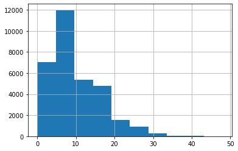

```python
df['windspeed'].hist()
```

```python
df['windforce'] = 0

# 바람의 세기가 사람에게 영향을 주는 지점인 29 이상일 때, 바람에게 영향을 받았다고 가정
df.loc[df['windspeed'] >= 29, 'windforce'] = 1
df.head()
```

|  | datetime | regular | casual | group | temp | dew | humid | windspeed | windforce |
| --- | --- | --- | --- | --- | --- | --- | --- | --- | --- |
| 0 | 2017-01-01 00:00:00 | 63.0 | 13.0 | 1.0 | -1 | -5 | 75 | 9 | 0 |
| 1 | 2017-01-01 01:00:00 | 55.0 | 21.0 | 0.0 | -2 | -5 | 80 | 9 | 0 |
| 2 | 2017-01-01 02:00:00 | 38.0 | 19.0 | 0.0 | -3 | -7 | 74 | 7 | 0 |
| 3 | 2017-01-01 03:00:00 | 22.0 | 12.0 | 0.0 | -3 | -6 | 80 | 4 | 0 |
| 4 | 2017-01-01 04:00:00 | 16.0 | 7.0 | 0.0 | -3 | -6 | 80 | 7 | 0 |

```python
# Q) 도메인 특성을 고려하여(주어진 데이터셋에 한정해서) 다른 개념을 더 적용할 여지가 있을까?
#    (단, 반드시 근거가 있어야 함)
#    hint: Besiness Understanding을 잘 생각
```

#### 날씨가 사람의 기분에 미치는 영향을 반영 - 불쾌지수(humidex)

- 불쾌지수: 온도와 이슬점을 이용해 땀이 증발하는 속도를 나타냄

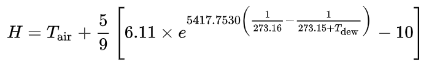

```python
T = 40
Td = 20   # humidex: 48

upper = 5417.7530 * ((1 / 273.16) - (1 / (273.15 + Td)))
inner = 6.11 * (2.71828 ** upper)
humidex = T + (5/9) * (inner - 10)
humidex
```

```
47.57052263851177
```

```python
def humidex_cal(T, Td):
    upper = 5417.7530 * ((1 / 273.16) - (1 / (273.15 + Td)))
    inner = 6.11 * (2.71828 ** upper)
    return T + (5/9) * (inner - 10)
```

```python
df['humidex'] = humidex_cal(df['temp'], df['dew'])
df.head()
```

|  | datetime | regular | casual | group | temp | dew | humid | windspeed | windforce | humidex |
| --- | --- | --- | --- | --- | --- | --- | --- | --- | --- | --- |
| 0 | 2017-01-01 00:00:00 | 63.0 | 13.0 | 1.0 | -1 | -5 | 75 | 9 | 0 | -4.212215 |
| 1 | 2017-01-01 01:00:00 | 55.0 | 21.0 | 0.0 | -2 | -5 | 80 | 9 | 0 | -5.212215 |
| 2 | 2017-01-01 02:00:00 | 38.0 | 19.0 | 0.0 | -3 | -7 | 74 | 7 | 0 | -6.542302 |
| 3 | 2017-01-01 03:00:00 | 22.0 | 12.0 | 0.0 | -3 | -6 | 80 | 4 | 0 | -6.382903 |
| 4 | 2017-01-01 04:00:00 | 16.0 | 7.0 | 0.0 | -3 | -6 | 80 | 7 | 0 | -6.382903 |

```python
# 불쾌지수 별로 구분

df['discomfort'] = 0
df.loc[df['humidex'] >= 30, 'discomfort'] = 1
df.loc[df['humidex'] >= 40, 'discomfort'] = 2
df.loc[df['humidex'] >= 46, 'discomfort'] = 3
df.head()
```

|  | datetime | regular | casual | group | temp | dew | humid | windspeed | windforce | humidex | discomfort |
| --- | --- | --- | --- | --- | --- | --- | --- | --- | --- | --- | --- |
| 0 | 2017-01-01 00:00:00 | 63.0 | 13.0 | 1.0 | -1 | -5 | 75 | 9 | 0 | -4.212215 | 0 |
| 1 | 2017-01-01 01:00:00 | 55.0 | 21.0 | 0.0 | -2 | -5 | 80 | 9 | 0 | -5.212215 | 0 |
| 2 | 2017-01-01 02:00:00 | 38.0 | 19.0 | 0.0 | -3 | -7 | 74 | 7 | 0 | -6.542302 | 0 |
| 3 | 2017-01-01 03:00:00 | 22.0 | 12.0 | 0.0 | -3 | -6 | 80 | 4 | 0 | -6.382903 | 0 |
| 4 | 2017-01-01 04:00:00 | 16.0 | 7.0 | 0.0 | -3 | -6 | 80 | 7 | 0 | -6.382903 | 0 |

#### 날씨가 사람의 건강에 미치는 영향

- 여름에는 열사병 위험, 겨울에 동상 위험
- heat index: http://www.decisionsciencenews.com/wp-content/uploads/2018/08/heat_index_chart.png
- wind chill: https://wiki.fis-ski.com/index.php/Wind_Chill_Index
- 열지수가 높으면 열사병 걸릴 확률 증가 -> 외부활동 저하 요인
- 겨울 체감온도는 동상 확률과 연관 -> 외부활동 저하 요인